# TUgas MPDW Pekan 3

Reynd Hamonangan Pasaribu - G1401211013

2023-09-18

#library

```r
library(dLagM)
library(nardl)
library(dynlm)
library(zoo)
library(MLmetrics)
library(lmtest)
```

#Impor Data

```r
data <- rio::import("https://raw.githubusercontent.com/reyndpasaribu/MPDW/main/Pertemuan%203/databj.csv")
```

#Pembagian Data

```r
#Split Data
train <-data[1:80,]
test <- data[81:100,]
```

```r
#Data Time Series
train.ts<-ts(train)
test.ts<-ts(test)
data.ts<-ts(data)
```

#Model Koyck

```r
model.koyck <- koyckDlm(x = train$open, y=train$close)
summary(model.koyck)
```

```
##
## Call:
## "Y ~ (Intercept) + Y.1 + X.t"
##
## Residuals:
##     Min      1Q  Median      3Q     Max
## -3772.9  -682.2   119.5   747.0  4845.6
##
## Coefficients:
##             Estimate Std. Error t value Pr(>|t|)
## (Intercept) -821.506   2358.581  -0.348    0.729
## Y.1           -1.308      2.609  -0.502    0.617
## X.t            2.326      2.642   0.880    0.381
##
## Residual standard error: 1377 on 76 degrees of freedom
## Multiple R-Squared: 0.9127,  Adjusted R-squared: 0.9104
## Wald test: 416.5 on 2 and 76 DF,  p-value: < 2.2e-16
##
## Diagnostic tests:
## NULL
##
##                              alpha     beta       phi
## Geometric coefficients:  -355.8721 2.326027 -1.308431
```

```r
AIC(model.koyck)
```

```
## [1] 1371.147
```

```r
BIC(model.koyck)
```

```
## [1] 1380.625
```

Dari hasil tersebut, didapat bahwa intercept , peubah $x_t$ dan $y_{t-1}$ memiliki nilai $P-Value>0.05$. Hal ini menunjukkan bahwa intercept, peubah $x_t$ dan $y_{t-1}$ tidak berpengaruh signifikan terhadap $y_t$. Adapun model keseluruhannya adalah sebagai berikut
$$\hat{Y_t}= -821.506 + 2.326 X_t - 1.308 Y_{t-1}$$
#Peramalan dan Akurasi

```r
fore.koyck <- forecast(model = model.koyck, x=test$open, h=20)
fore.koyck
```

```
## $forecasts
##  [1] 54657.29 53385.00 57838.60 56084.25 57216.69 53874.15 56037.91 54486.09
##  [9] 54423.11 55901.13 49780.39 59624.19 47465.33 62678.87 42717.18 68554.22
## [17] 30712.60 76573.87 13301.84 96889.04
##
## $call
## forecast.koyckDlm(model = model.koyck, x = test$open, h = 20)
##
## attr(,"class")
## [1] "forecast.koyckDlm" "dLagM"
```

#MAPE

```r
mape.koyck <- MAPE(fore.koyck$forecasts, test$close)
GoF(model.koyck)
```

```
##              n     MAE          MPE       MAPE      sMAPE     MASE     MSE
## model.koyck 79 993.234 -0.000397311 0.02127153 0.02125206 1.415742 1825115
##                 MRAE    GMRAE
## model.koyck 3.994251 1.588254
```

#Pemodelan dengan Regression Distributed Lag (Lag=2)

```r
model.dlm2 <- dlm(x = train$open, y=train$close,q=2)
summary(model.dlm2)
```

```
##
## Call:
## lm(formula = model.formula, data = design)
##
## Residuals:
##     Min      1Q  Median      3Q     Max
## -3458.5  -533.6    62.0   626.5  2494.1
##
## Coefficients:
##              Estimate Std. Error t value Pr(>|t|)
## (Intercept)  259.4754  1278.5846   0.203    0.840
## x.t            0.9353     0.1021   9.159 8.32e-14 ***
## x.1            0.1553     0.1391   1.116    0.268
## x.2           -0.0948     0.1033  -0.918    0.362
## ---
## Signif. codes:  0 '***' 0.001 '**' 0.01 '*' 0.05 '.' 0.1 ' ' 1
##
## Residual standard error: 1047 on 74 degrees of freedom
## Multiple R-squared:  0.9507, Adjusted R-squared:  0.9487
## F-statistic: 475.4 on 3 and 74 DF,  p-value: < 2.2e-16
##
## AIC and BIC values for the model:
##        AIC      BIC
## 1 1312.067 1323.851
```

```r
AIC(model.dlm2)
```

```
## [1] 1312.067
```

```r
BIC(model.dlm2)
```

```
## [1] 1323.851
```

Dari hasil diatas, didapat bahwa $P-value$ dari $x_{t}<0.05$. Hal ini menunjukkan bahwa $x_{t}$ berpengaruh signifikan terhadap $y_t$. Adapun model keseluruhan yang terbentuk adalah sebagai berikut

$$\hat{Y_t}= 259.4754 + 0.9353 X_t + 0.1553 X_{t-1} - 0.0948 X_{t-2}$$

#Peramalan dan Akurasi

```r
fore.dlm <- forecast(model = model.dlm2, x=test$open, h=20)
fore.dlm
```

```
## $forecasts
##  [1] 54568.34 54179.25 55166.96 57028.81 56719.48 55727.60 54762.21 55204.90
##  [9] 54538.62 54907.87 53402.86 53804.34 54387.46 54081.17 53982.89 53894.34
## [17] 52255.09 50528.67 49136.13 49388.62
##
## $call
## forecast.dlm(model = model.dlm2, x = test$open, h = 20)
##
## attr(,"class")
## [1] "forecast.dlm" "dLagM"
```

#MAPE Model DLM

```r
mape.dlm2 <- MAPE(fore.dlm$forecasts, test$close)
#akurasi data training
GoF(model.dlm2)
```

```
##             n      MAE           MPE       MAPE      sMAPE     MASE     MSE
## model.dlm2 78 784.4311 -0.0004658108 0.01660593 0.01656522 1.106918 1040586
##               MRAE    GMRAE
## model.dlm2 2.53788 1.419472
```

#Lag Optimum

```r
#penentuan lag optimum
finiteDLMauto(formula = close ~ open,
              data = data.frame(train), q.min = 1, q.max = 10,
              model.type = "dlm", error.type = "AIC", trace = F)
```

```
##    q - k    MASE      AIC      BIC   GMRAE   MBRAE R.Adj.Sq Ljung-Box
## 10    10 1.06974 1195.078 1224.308 1.21427 0.48458   0.9451 0.2627572
```

Berdasarkan output tersebut, lag optimum didapatkan ketika lag=10. Selanjutnya dilakukan pemodelan untuk lag=10

```r
model.dlm10 <- dlm(x = train$open, y=train$close,q=10)
summary(model.dlm10)
```

```
##
## Call:
## lm(formula = model.formula, data = design)
##
## Residuals:
##     Min      1Q  Median      3Q     Max
## -3288.8  -495.9    78.7   513.8  2291.9
##
## Coefficients:
##               Estimate Std. Error t value Pr(>|t|)
## (Intercept)  963.81776 1539.41538   0.626    0.534
## x.t            0.97300    0.11569   8.411 1.26e-11 ***
## x.1            0.09175    0.16078   0.571    0.570
## x.2           -0.16427    0.16151  -1.017    0.313
## x.3            0.20057    0.16154   1.242    0.219
## x.4           -0.08309    0.16190  -0.513    0.610
## x.5           -0.01958    0.16181  -0.121    0.904
## x.6            0.05123    0.16146   0.317    0.752
## x.7           -0.01590    0.16090  -0.099    0.922
## x.8            0.01474    0.15720   0.094    0.926
## x.9           -0.01382    0.15616  -0.089    0.930
## x.10          -0.05403    0.11414  -0.473    0.638
## ---
## Signif. codes:  0 '***' 0.001 '**' 0.01 '*' 0.05 '.' 0.1 ' ' 1
##
## Residual standard error: 1125 on 58 degrees of freedom
## Multiple R-squared:  0.9539, Adjusted R-squared:  0.9451
## F-statistic:   109 on 11 and 58 DF,  p-value: < 2.2e-16
##
## AIC and BIC values for the model:
##        AIC      BIC
## 1 1195.078 1224.308
```

```r
AIC(model.dlm10)
```

```
## [1] 1195.078
```

```r
BIC(model.dlm10)
```

```
## [1] 1224.308
```

```r
#peramalan dan akurasi
fore.dlm10 <- forecast(model = model.dlm10, x=test$open, h=20)
mape.dlm10<- MAPE(fore.dlm10$forecasts, test$close)
#akurasi data training
GoF(model.dlm10)
```

```
##              n      MAE           MPE       MAPE      sMAPE     MASE     MSE
## model.dlm10 70 756.1173 -0.0004721363 0.01607083 0.01603068 1.069736 1048882
##                 MRAE    GMRAE
## model.dlm10 2.328846 1.214266
```

Model tersebut merupakan model yang sangat baik dengan nilai MAPE yang kurang dari 10%.

#Model AUtoregressive

```r
#Model ardl
model.ardl <- ardlDlm(x = train$open, y = train$close, p = 1 , q = 1)
summary(model.ardl)
```

```
##
## Time series regression with "ts" data:
## Start = 2, End = 80
##
## Call:
## dynlm(formula = as.formula(model.text), data = data, start = 1)
##
## Residuals:
##     Min      1Q  Median      3Q     Max
## -3228.6  -530.3    10.0   617.6  2289.3
##
## Coefficients:
##               Estimate Std. Error t value Pr(>|t|)
## (Intercept)  897.74040 1184.64797   0.758 0.450938
## X.t            0.04696    0.26056   0.180 0.857470
## X.1           -0.13138    0.10890  -1.206 0.231464
## Y.1            1.06806    0.29173   3.661 0.000465 ***
## ---
## Signif. codes:  0 '***' 0.001 '**' 0.01 '*' 0.05 '.' 0.1 ' ' 1
##
## Residual standard error: 975.5 on 75 degrees of freedom
## Multiple R-squared:  0.9568, Adjusted R-squared:  0.9551
## F-statistic: 553.5 on 3 and 75 DF,  p-value: < 2.2e-16
```

```r
AIC(model.ardl)
```

```
## [1] 1317.599
```

```r
BIC(model.ardl)
```

```
## [1] 1329.446
```

Hasil di atas menunjukkan bahwa peubah $y_{t-1}$ memiliki nilai p-value $<0.05$ Hal ini menunjukkan bahwa peubah $y_{t-1}$ berpengaruh signifikan terhadap $y_t$, sementara peubah $x_t$ dan $x_{t-1}$ tidak berpengaruh signifikan terhadap $y_t$. Model keseluruhannya adalah sebagai berikut:

$$\hat{Y}= 897.74040 + 0.04696 X_t -0.13138 X_{t-1} + 1.06806 Y_{t-1}$$

#Peramalan dan Akurasi

```r
fore.ardl <- forecast(model = model.ardl, x=test$open, h=20)
fore.ardl
```

```
## $forecasts
##  [1] 54498.54 54490.09 54589.91 54621.23 54401.16 54194.24 54033.72 54012.91
##  [9] 53876.17 53876.54 53713.58 53813.06 53830.21 53793.76 53792.98 53789.62
## [17] 53720.46 53800.81 54026.96 54469.10
##
## $call
## forecast.ardlDlm(model = model.ardl, x = test$open, h = 20)
##
## attr(,"class")
## [1] "forecast.ardlDlm" "dLagM"
```

```r
mape.ardl <- MAPE(fore.ardl$forecasts, test$close)
mape.ardl
```

```
## [1] 0.02472527
```

```r
#akurasi data training
GoF(model.ardl)
```

```
##             n      MAE          MPE       MAPE      sMAPE     MASE      MSE
## model.ardl 79 716.5312 -0.000413225 0.01529879 0.01526993 1.021334 903482.4
##                MRAE    GMRAE
## model.ardl 1.552895 1.102429
```

Berdasarkan akurasi di atas, terlihat bahwa nilai MAPE keduanya tidak jauh berbeda. Artinya, model regresi dengan distribusi lag ini tidak`overfitted`atau`underfitted`

#Lag Optimum

```r
#penentuan lag optimum
model.ardl.opt <- ardlBoundOrders(data = data.frame(data), ic = "AIC",
                                  formula = close ~ open)
min_p=c()
for(i in 1:6){
  min_p[i]=min(model.ardl.opt$Stat.table[[i]])
}
q_opt=which(min_p==min(min_p, na.rm = TRUE))
p_opt=which(model.ardl.opt$Stat.table[[q_opt]] ==
              min(model.ardl.opt$Stat.table[[q_opt]], na.rm = TRUE))
data.frame("q_optimum" = q_opt, "p_optimum" = p_opt,
           "AIC"=model.ardl.opt$min.Stat)
```

```
##   q_optimum p_optimum      AIC
## 1         1        15 1419.507
```

Dari tabel di atas, dapat terlihat bahwa nilai AIC terendah didapat ketika $p=15$ dan $q=1$, yaitu sebesar `1419.507`. Artinya, model autoregressive optimum didapat ketika $p=15$ dan $q=1$.

Selanjutnya dapat dilakukan pemodelan dengan nilai $p$ dan $q$ optimum seperti inisialisasi di langkah sebelumnya.

# Lag optimum (p=15 dan q=1)

```r
model.opt <- ardlDlm(x = train$close, y = train$open, p = 15 , q = 1)
summary(model.opt)
```

```
##
## Time series regression with "ts" data:
## Start = 16, End = 80
##
## Call:
## dynlm(formula = as.formula(model.text), data = data, start = 1)
##
## Residuals:
##      Min       1Q   Median       3Q      Max
## -1404.49  -162.58    51.47   232.35   553.28
##
## Coefficients:
##               Estimate Std. Error t value Pr(>|t|)
## (Intercept) 934.318909 612.730366   1.525    0.134
## X.t          -0.038456   0.061272  -0.628    0.533
## X.1           1.034215   0.089810  11.516 2.78e-15 ***
## X.2          -0.076522   0.170424  -0.449    0.655
## X.3           0.095097   0.089483   1.063    0.293
## X.4           0.022375   0.087094   0.257    0.798
## X.5          -0.140198   0.086766  -1.616    0.113
## X.6          -0.032630   0.087797  -0.372    0.712
## X.7           0.099995   0.085306   1.172    0.247
## X.8           0.020717   0.085384   0.243    0.809
## X.9           0.000206   0.081966   0.003    0.998
## X.10         -0.051240   0.082557  -0.621    0.538
## X.11          0.013560   0.082289   0.165    0.870
## X.12          0.106370   0.082591   1.288    0.204
## X.13         -0.069827   0.083671  -0.835    0.408
## X.14         -0.085191   0.083835  -1.016    0.315
## X.15          0.081387   0.056247   1.447    0.155
## Y.1           0.003358   0.134222   0.025    0.980
## ---
## Signif. codes:  0 '***' 0.001 '**' 0.01 '*' 0.05 '.' 0.1 ' ' 1
##
## Residual standard error: 402.2 on 47 degrees of freedom
## Multiple R-squared:  0.9943, Adjusted R-squared:  0.9923
## F-statistic: 484.7 on 17 and 47 DF,  p-value: < 2.2e-16
```

```r
AIC(model.opt)
```

```
## [1] 980.9955
```

```r
BIC(model.opt)
```

```
## [1] 1022.309
```

Hasil di atas menunjukkan bahwa peubah $x_{t-1}$, hasil uji t menunjukkan nilai-p pada peubah $<0.05$ Hal ini menunjukkan bahwa peubah $x_{t-1}$ berpengaruh signifikan terhadap $y_t$, sementara x lainnya tidak berpengaruh signifikan terhadap $y_t$. Model keseluruhannya adalah sebagai berikut:

$$\hat{Y_t}= 934.318909 - 0.038456 X_t + 1.034215 X_{t-1} - 0.076522
X_{t-2} + 0.095097 X_{t-3} + 0.022375 X_{t-4} - 0.140198 X_{t-5} -
0.032630 X_{t-6} + 0.099995 X_{t-7} + 0.020717 X_{t-8} + 0.000206
X_{t-9} - 0.051240 X_{t-10} + 0.013560 X_{t-11} + 0.106370 X_{t-12} -
0.069827 X_{t-13} - 0.085191 X_{t-14} + 0.081387 X_{t-15} + 0.003358 Y_t$$

# Peramalan dan akurasi model Autoregressive dengan lag optimum (p=15 dan q=1)

```r
# peramalan 20 periode kedepan
frc.opt <- forecast(model = model.opt, x=test$close, h=20)
frc.opt
```

```
## $forecasts
##  [1] 54294.34 54367.97 55182.83 56621.75 55905.11 55650.68 54655.98 54677.64
##  [9] 54085.37 54621.79 53323.56 53758.12 53921.87 53896.72 54338.11 54100.30
## [17] 52851.25 53627.20 48769.45 49630.36
##
## $call
## forecast.ardlDlm(model = model.opt, x = test$close, h = 20)
##
## attr(,"class")
## [1] "forecast.ardlDlm" "dLagM"
```

```r
#akurasi data test
mape.opt <- MAPE(frc.opt$forecasts, test$open)
mape.opt
```

```
## [1] 0.008287217
```

```r
#akurasi data training
GoF(model.opt)
```

```
##            n      MAE           MPE        MAPE       sMAPE      MASE      MSE
## model.opt 65 258.9982 -5.538222e-05 0.005404444 0.005398366 0.2955599 116978.5
##                   MRAE     GMRAE
## model.opt 120662192954 0.7205973
```

Berdasarkan akurasi di atas, terlihat bahwa nilai MAPE keduanya tidak jauh berbeda. Artinya, model regresi dengan distribusi lag ini tidak`overfitted atau`underfitted`

```r
#sama dengan model dlm q = 2
cons_lm1 <- dynlm(close ~ open+L(close)+L(close,2),data = train.ts)
#sama dengan model ardl p = 10
cons_lm2 <- dynlm(close ~ open+L(open)+L(open,2)+L(open,3)+L(open,4)+L(open,5)+L(open,6)+L(open,7)+L(open,8)+L(open,9)+L(open,10),data = train.ts)
#sama dengan ardl p=1 q=1
cons_lm3 <- dynlm(close ~ open+L(open)+close+L(close),data = train.ts)
#sama dengan dlm p = 15 q=1
cons_lm4 <- dynlm(close ~ open+L(open)+L(open,2)+L(open,3)+L(open,4)+L(open,5)+L(open,6)+L(open,7)+L(open,8)+L(open,9)+L(open,10)+L(open,11)+L(open,12)+L(open,13)+L(open,14)+L(open,15)+close+L(close),data = train.ts)
#sama dengan ardl
```

```r
summary(cons_lm1)
```

```
##
## Time series regression with "ts" data:
## Start = 3, End = 80
##
## Call:
## dynlm(formula = close ~ open + L(close) + L(close, 2), data = train.ts)
##
## Residuals:
##     Min      1Q  Median      3Q     Max
## -3291.2  -515.6    12.2   605.7  2244.5
##
## Coefficients:
##               Estimate Std. Error t value Pr(>|t|)
## (Intercept)  745.60600 1169.54388   0.638 0.525755
## open           0.02225    0.25957   0.086 0.931921
## L(close)       1.14931    0.29986   3.833 0.000264 ***
## L(close, 2)   -0.18529    0.11650  -1.590 0.116003
## ---
## Signif. codes:  0 '***' 0.001 '**' 0.01 '*' 0.05 '.' 0.1 ' ' 1
##
## Residual standard error: 963.3 on 74 degrees of freedom
## Multiple R-squared:  0.9583, Adjusted R-squared:  0.9566
## F-statistic: 566.4 on 3 and 74 DF,  p-value: < 2.2e-16
```

```r
summary(cons_lm2)
```

```
##
## Time series regression with "ts" data:
## Start = 11, End = 80
##
## Call:
## dynlm(formula = close ~ open + L(open) + L(open, 2) + L(open,
##     3) + L(open, 4) + L(open, 5) + L(open, 6) + L(open, 7) +
##     L(open, 8) + L(open, 9) + L(open, 10), data = train.ts)
##
## Residuals:
##     Min      1Q  Median      3Q     Max
## -3288.8  -495.9    78.7   513.8  2291.9
##
## Coefficients:
##               Estimate Std. Error t value Pr(>|t|)
## (Intercept)  963.81776 1539.41538   0.626    0.534
## open           0.97300    0.11569   8.411 1.26e-11 ***
## L(open)        0.09175    0.16078   0.571    0.570
## L(open, 2)    -0.16427    0.16151  -1.017    0.313
## L(open, 3)     0.20057    0.16154   1.242    0.219
## L(open, 4)    -0.08309    0.16190  -0.513    0.610
## L(open, 5)    -0.01958    0.16181  -0.121    0.904
## L(open, 6)     0.05123    0.16146   0.317    0.752
## L(open, 7)    -0.01590    0.16090  -0.099    0.922
## L(open, 8)     0.01474    0.15720   0.094    0.926
## L(open, 9)    -0.01382    0.15616  -0.089    0.930
## L(open, 10)   -0.05403    0.11414  -0.473    0.638
## ---
## Signif. codes:  0 '***' 0.001 '**' 0.01 '*' 0.05 '.' 0.1 ' ' 1
##
## Residual standard error: 1125 on 58 degrees of freedom
## Multiple R-squared:  0.9539, Adjusted R-squared:  0.9451
## F-statistic:   109 on 11 and 58 DF,  p-value: < 2.2e-16
```

```r
summary(cons_lm3)
```

```
##
## Time series regression with "ts" data:
## Start = 2, End = 80
##
## Call:
## dynlm(formula = close ~ open + L(open) + close + L(close), data = train.ts)
##
## Residuals:
##     Min      1Q  Median      3Q     Max
## -3228.6  -530.3    10.0   617.6  2289.3
##
## Coefficients:
##               Estimate Std. Error t value Pr(>|t|)
## (Intercept)  897.74040 1184.64797   0.758 0.450938
## open           0.04696    0.26056   0.180 0.857470
## L(open)       -0.13138    0.10890  -1.206 0.231464
## L(close)       1.06806    0.29173   3.661 0.000465 ***
## ---
## Signif. codes:  0 '***' 0.001 '**' 0.01 '*' 0.05 '.' 0.1 ' ' 1
##
## Residual standard error: 975.5 on 75 degrees of freedom
## Multiple R-squared:  0.9568, Adjusted R-squared:  0.9551
## F-statistic: 553.5 on 3 and 75 DF,  p-value: < 2.2e-16
```

```r
summary(cons_lm4)
```

```
##
## Time series regression with "ts" data:
## Start = 16, End = 80
##
## Call:
## dynlm(formula = close ~ open + L(open) + L(open, 2) + L(open,
##     3) + L(open, 4) + L(open, 5) + L(open, 6) + L(open, 7) +
##     L(open, 8) + L(open, 9) + L(open, 10) + L(open, 11) + L(open,
##     12) + L(open, 13) + L(open, 14) + L(open, 15) + close + L(close),
##     data = train.ts)
##
## Residuals:
##     Min      1Q  Median      3Q     Max
## -2115.2  -605.1    70.7   429.3  1808.3
##
## Coefficients:
##               Estimate Std. Error t value Pr(>|t|)
## (Intercept)  1.248e+03  1.398e+03   0.893 0.376413
## open        -2.475e-01  3.133e-01  -0.790 0.433511
## L(open)     -7.592e-03  1.492e-01  -0.051 0.959642
## L(open, 2)  -1.163e-01  1.427e-01  -0.815 0.418955
## L(open, 3)   1.979e-01  1.414e-01   1.399 0.168245
## L(open, 4)  -1.691e-01  1.391e-01  -1.216 0.230144
## L(open, 5)  -2.753e-02  1.340e-01  -0.205 0.838134
## L(open, 6)   7.492e-02  1.327e-01   0.564 0.575140
## L(open, 7)   3.313e-02  1.343e-01   0.247 0.806294
## L(open, 8)  -8.140e-03  1.312e-01  -0.062 0.950787
## L(open, 9)  -2.418e-02  1.323e-01  -0.183 0.855793
## L(open, 10)  1.319e-01  1.309e-01   1.008 0.318840
## L(open, 11) -1.501e-01  1.356e-01  -1.106 0.274176
## L(open, 12) -2.547e-01  1.368e-01  -1.861 0.068944 .
## L(open, 13)  3.443e-02  1.388e-01   0.248 0.805206
## L(open, 14)  1.489e-01  1.369e-01   1.087 0.282387
## L(open, 15)  9.124e-02  1.074e-01   0.850 0.399777
## L(close)     1.273e+00  3.336e-01   3.815 0.000397 ***
## ---
## Signif. codes:  0 '***' 0.001 '**' 0.01 '*' 0.05 '.' 0.1 ' ' 1
##
## Residual standard error: 903 on 47 degrees of freedom
## Multiple R-squared:  0.9721, Adjusted R-squared:  0.962
## F-statistic: 96.28 on 17 and 47 DF,  p-value: < 2.2e-16
```

#SSE

```r
deviance(cons_lm1)
```

```
## [1] 68666970
```

```r
deviance(cons_lm2)
```

```
## [1] 73421713
```

```r
deviance(cons_lm3)
```

```
## [1] 71375114
```

```r
deviance(cons_lm4)
```

```
## [1] 38322978
```

#Autokorelasi

```r
dwtest(cons_lm1)  #Tidak ada autokorelasi
```

```
##
##  Durbin-Watson test
##
## data:  cons_lm1
## DW = 2.0181, p-value = 0.4713
## alternative hypothesis: true autocorrelation is greater than 0
```

```r
dwtest(cons_lm2)  #Tidak ada autokorelasi
```

```
##
##  Durbin-Watson test
##
## data:  cons_lm2
## DW = 1.721, p-value = 0.1069
## alternative hypothesis: true autocorrelation is greater than 0
```

```r
dwtest(cons_lm3)  #Tidak ada autokorelasi
```

```
##
##  Durbin-Watson test
##
## data:  cons_lm3
## DW = 1.8886, p-value = 0.2604
## alternative hypothesis: true autocorrelation is greater than 0
```

```r
dwtest(cons_lm4)  #Tidak ada autokorelasi
```

```
##
##  Durbin-Watson test
##
## data:  cons_lm4
## DW = 2.0296, p-value = 0.4651
## alternative hypothesis: true autocorrelation is greater than 0
```

#Heterogenitas

```r
bptest(cons_lm1)  #Homogen
```

```
##
##  studentized Breusch-Pagan test
##
## data:  cons_lm1
## BP = 1.3921, df = 3, p-value = 0.7074
```

```r
bptest(cons_lm2)  #Homogen
```

```
##
##  studentized Breusch-Pagan test
##
## data:  cons_lm2
## BP = 5.1229, df = 11, p-value = 0.9251
```

```r
bptest(cons_lm3)  #Homogen
```

```
##
##  studentized Breusch-Pagan test
##
## data:  cons_lm3
## BP = 1.5419, df = 3, p-value = 0.6726
```

```r
bptest(cons_lm4)  #Homogen
```

```
##
##  studentized Breusch-Pagan test
##
## data:  cons_lm4
## BP = 8.7136, df = 17, p-value = 0.9488
```

#Kenormalan

```r
shapiro.test(residuals(cons_lm1))  #Normal
```

```
##
##  Shapiro-Wilk normality test
##
## data:  residuals(cons_lm1)
## W = 0.97903, p-value = 0.2262
```

```r
shapiro.test(residuals(cons_lm2))  #Tidak normal
```

```
##
##  Shapiro-Wilk normality test
##
## data:  residuals(cons_lm2)
## W = 0.9626, p-value = 0.03492
```

```r
shapiro.test(residuals(cons_lm3))  #Normal
```

```
##
##  Shapiro-Wilk normality test
##
## data:  residuals(cons_lm3)
## W = 0.98044, p-value = 0.2667
```

```r
shapiro.test(residuals(cons_lm4))  #Normal
```

```
##
##  Shapiro-Wilk normality test
##
## data:  residuals(cons_lm4)
## W = 0.98491, p-value = 0.6142
```

#Perbandingan Model

```r
akurasi <- matrix(c(mape.koyck, mape.dlm2, mape.dlm10, mape.opt))
row.names(akurasi)<- c("Koyck","DLM 1","DLM 2","Autoregressive")
colnames(akurasi) <- c("MAPE")
akurasi
```

```
##                       MAPE
## Koyck          0.190420989
## DLM 1          0.012671055
## DLM 2          0.013431708
## Autoregressive 0.008287217
```

#Plot

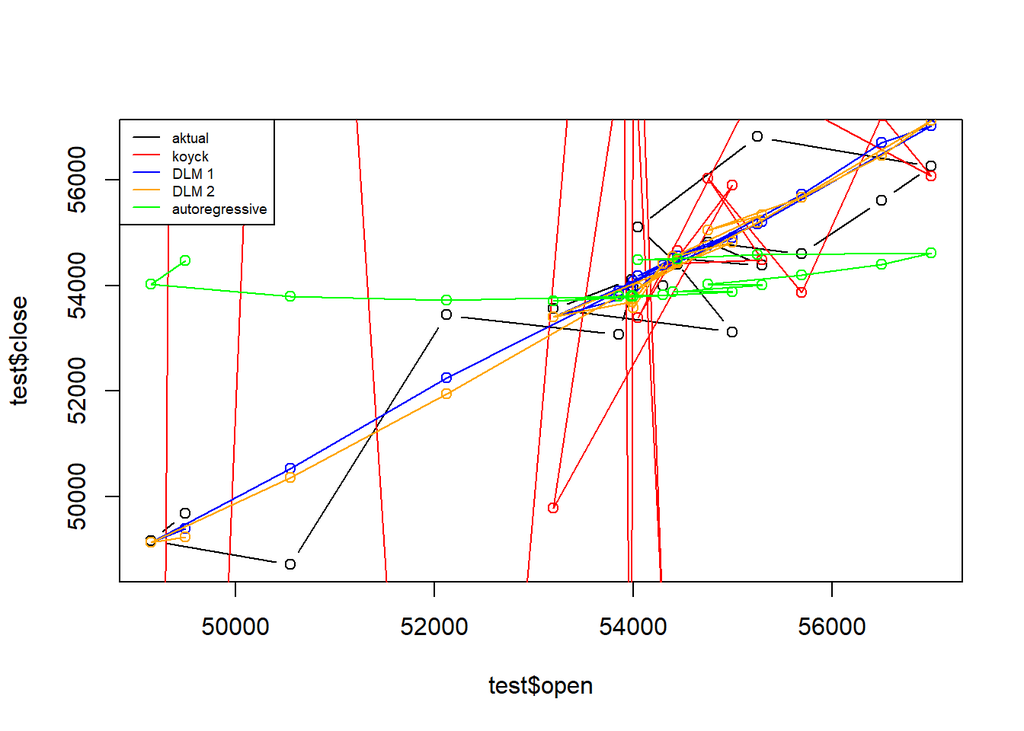

```r
par(mfrow=c(1,1))
plot(test$open, test$close, type="b", col="black")
points(test$open, fore.koyck$forecasts,col="red")
lines(test$open, fore.koyck$forecasts,col="red")
points(test$open, fore.dlm$forecasts,col="blue")
lines(test$open, fore.dlm$forecasts,col="blue")
points(test$open, fore.dlm10$forecasts,col="orange")
lines(test$open, fore.dlm10$forecasts,col="orange")
points(test$open, fore.ardl$forecasts,col="green")
lines(test$open, fore.ardl$forecasts,col="green")
legend("topleft",c("aktual", "koyck","DLM 1","DLM 2", "autoregressive"), lty=1, col=c("black","red","blue","orange","green"), cex=0.6)
```